# SRM Chapter 2.2

theBudgetActuary

# Intro

Last section we found how to take data and find the parameters of a Simple Linear Regression model. We then learned to make predictions from the model and use residuals to judge overall model performance.

In this section we learn how to judge the performance of individual predictors in the model instead of the model as a whole. Next, we will learn to form confidence and prediction intervals to generalize our models from a sample to the entire population.

# Significance of a Predictor

There are three ways to check for the significance of a predictor: t-tests, confidence intervals, and p-values.

## T-tests:

A t-test can be used to decide whether or not a **single** predictor is statistically significant. What statistically significant means in this case is that the predictor plays a significant part in predicting the dependent variable.

An example would be if we were trying to predict the amount it will rain today. If we were using the Dow Jones average as a predictor, it is highly unlikely it would be the least bit significant, meaning using the Dow Jones average as a predictor will not help in predicting whether or not it will rain today. However, if instead we were using a predictor of the humidity in the air to predict rainfall, it is much more likely that it would be found to be statistically significant.

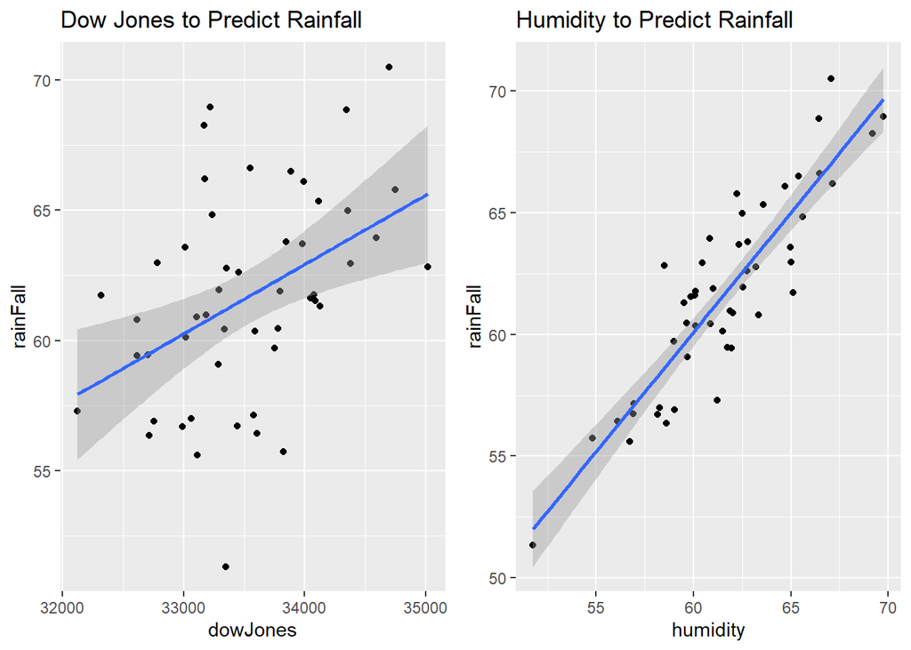

As you can see the humidity is able to yield results much closer to the rainfall for that day than the Dow Jones average is, suggesting it is likely a more significant predictor.

T-tests can also be used on the intercept to check whether or not it is statistically significant. However, in practice you will never want to drop the intercept as it can bias the results.

Now that we learned the interpretation of a t-test on a predictor, we will learn how to solve for it algebraically.

## *Hypothesis Test for two-tailed t-tests:*

> $H_{0}:$ Null Hypothesis - There is no relationship between predictor x and dependent variable y.

> $H_{a}:$ Alternative Hypothesis - There is a relationship between predictor x and dependent variable y.

> $H_{0}:$ $\beta_{1}=0$

> $H_{a}:$ $\beta_{1}\neq0$

> $se_{\beta_{0}}$ = $\sqrt{MSE\left(\frac{1}{n} + \frac{\bar{x}^{2}}{\sum_{i=1}^{n} (x_{i} - \bar{x})^{2}}\right)}$

> $se_{\beta_{1}}$ = $\sqrt{MSE\left(\frac{1}{\sum_{i=1}^{n} (x_{i} - \bar{x})^{2}}\right)}$

> t-statistic: $\frac{estimate - hypothesizedValue}{standard Error}$

**Reject if:** |t-statistic| $\ge t_{\alpha/2,n-p-1}$

$James, ISLR, p.(66-67)$

Notice the region where we fail to reject is the same as saying that the coefficient value for that predictor, $\beta_{1}$, can not be proven to be a value other than 0. If $\beta_{1}$ were 0, it means that the predictor has no affect on the dependent variable. For no matter what values the predictor contains, they will be multiplied by 0: $y=\beta_{0}+\beta_{1}(0)$. If we were using an $\alpha$ value of .05 and fail to reject, then we can say we are not 95% confident that the true population parameter is not 0.

### One-tailed t-tests

Two-tailed tests are used to check for significance of the $\beta$ parameter from 0. To check whether an estimated parameter value is above or below a certain value we use a one-tailed t-test.

### Left-tailed test

If we took a sample and had a SLR equation of y = 20 + 4(x) and we believed the true population parameter estimate of $\beta_{1}$ was less than 3, we can use a left-tailed test.

> $H_{0}$: $\beta_{1}>3$

> $H_{a}$: $\beta_{1}\le 3$

> t-statistic: $\frac{estimate - hypothesizedValue}{standard Error}$

**Reject if:** t-statistic $\le -t_{\alpha,n-p-1}$

$James, ISLR, p.(66-67)$

When using a one-tailed test the t-score is the same. The only difference is the rejection region where in two-tailed we use $\alpha$/2 and for one-tailed we use $\alpha$.

### Right-tailed test

If instead we were trying to predict if a parameter estimate was greater than 3 we would use a right-tailed test.

> $H_{0}$: $\beta_{1}<3$

> $H_{a}$: $\beta_{1}\ge 3$

> t-statistic: $\frac{estimate - hypothesizedValue}{standard Error}$

**Reject if:** t-statistic $\ge t_{\alpha,n-p-1}$

When forming the null and alternative hypothesis, an easy way to remember the setup is that for right-tailed the alternative hypothesis ($H_{a}$) points right and for left-tailed the alternative hypothesis points left. The alternative is what your trying to prove so left-tailed means trying to prove less than some number, right-tailed means trying to prove greater than some number.

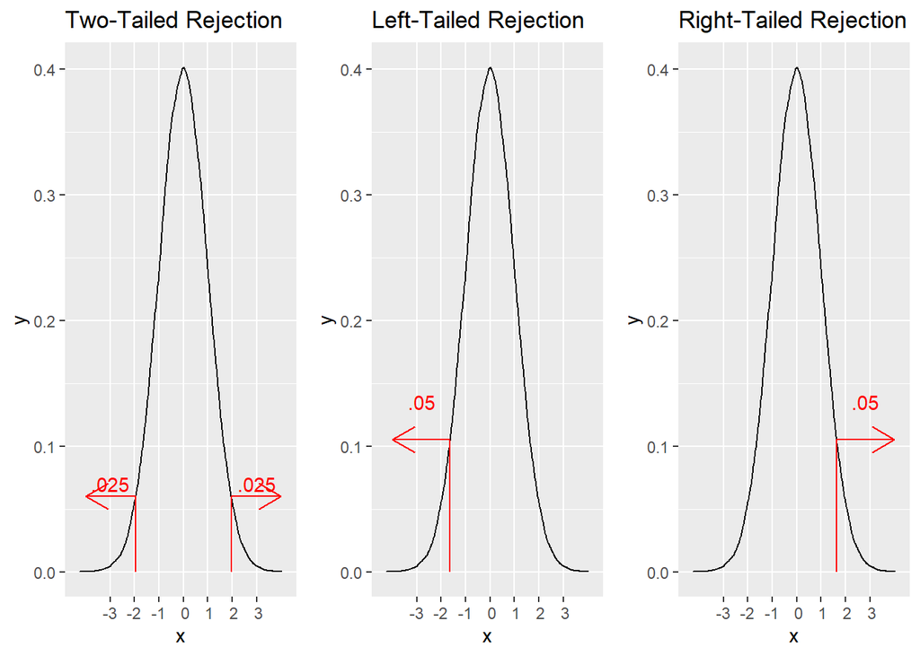

## **Confidence Intervals:**

When we found $\beta_{0}$ and $\beta_{1}$ in the last section these were just estimates from one sample. If we want to see where the true population lies, we can use a confidence interval. When using a 95% percent confidence interval from a sample parameter, what we are saying is that there is a 95% chance that the true population parameter falls within the confidence interval range. $James, ISLR, p.66$

Example: If we have a confidence interval for $\hat{\beta}_{1}$ of (-5,10), if using a 95% confidence interval, we can say that we are 95% confident that the population parameter of $\beta_{1}$ falls within the interval of -5 to 10.

Confidence intervals for $\beta_{0}$ and $\beta_{1}$ parameters:

> $\beta_{j}\pm t_{\underset{a}{(1-k)}/2,n-p-1}*se_{bj}$

> *notice the $\alpha$ value is divided by 2. This is because it is a two tailed test.

> *MSE is an estimate of the $Var(\epsilon)$

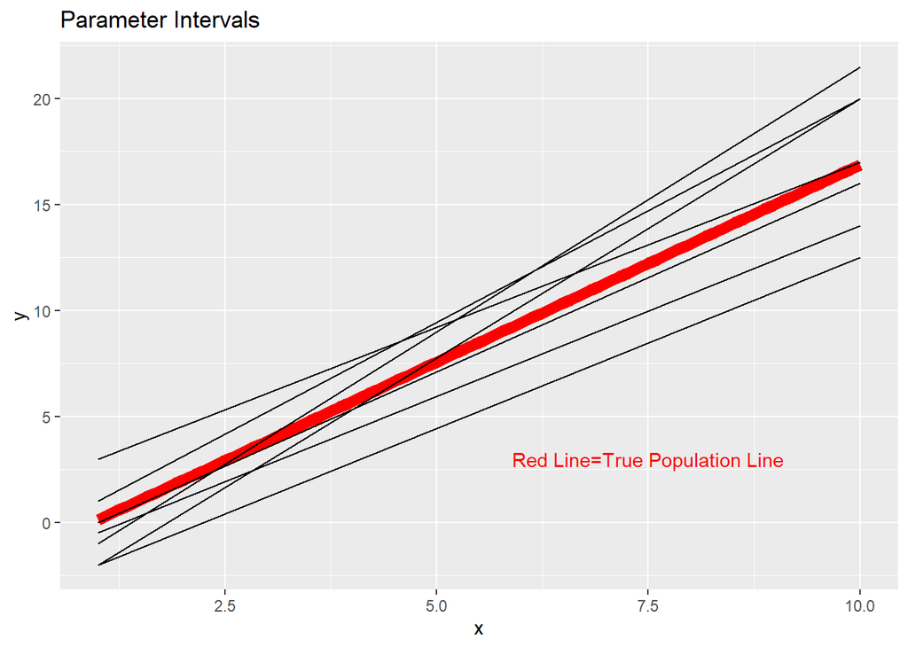

sample 1: (y=5+6x) +

sample 2: (y=4+7x) +

sample 3: (y=4+6.5x) +

sample 4: (y=3.5+7.2x) +

…

$\frac{1}{n}\sum_{i=1}^{n \rightarrow\infty} \beta_{0} \rightarrow$ true $\beta_{0}$

$\frac{1}{n}\sum_{i=1}^{n \rightarrow\infty} \beta_{1} \rightarrow$ true $\beta_{1}$

A confidence interval can also be used to check whether or not a predictor is significant. If the range of values formed from a confidence interval contains the value 0, then the predictor is not significant. For instance, if the $\beta_{1}$ 95% confidence interval is (-2,8) what we are saying is that we cannot be 95% sure that the true population parameter is not 0.

## P-Value

P-values are the final of the 3 ways to check if a predictor is significant. P-values are found using a t-table. If the p-value if less than the significance level being tested then we say the predictor is significant. In a one tailed test if using a $\alpha$ value of .05, or 95% confidence, if a p-value of less than .05 is found reject the null hypothesis. For a two-tailed test if the p-value is less than $\alpha /2$, so for a 95% confidence interval less than .025, reject the null hypothesis.

# **Confidence Intervals vs Prediction Intervals for Predictions:**

## Confidence Intervals

We formed confidence intervals for our parameters, now we will form confidence intervals for our predictions. A confidence interval creates a range of the **mean** response values.

For instance, if we are trying to predict the weights of students based off their heights, our SLR formula might look like this: weight = 20 + 1.5(height). If a student was 50 inches tall our prediction would be 95 pounds. However, not every student that is 50 inches tall weighs 95 pounds. In fact, it’s possible none of them are. A confidence interval states that if we average the weight of every student that is 50 inches tall together, their average weight will fall within a specified range called the confidence interval.

## Prediction Intervals

Prediction intervals use the same logic as confidence intervals, the difference is that confidence intervals find the range of the mean responses while a prediction interval finds the range of a **single** response. So in the previous example a prediction interval would show the range of possible weights for a single student that is 50 inches tall instead of the mean of all students that are 50 inches tall.

> $se_{confidence Interval}$ = $\sqrt{MSE\left(\frac{1}{n}+\frac{(x-\bar{x})^{2}}{\sum_{i=1}^{n}(x_{i}-\bar{x})^{2}}\right)}$

> $se_{prediction Interval}$ = $\sqrt{MSE\left(1+\frac{1}{n}+\frac{(x_{n+1}-\bar{x})^{2}}{\sum_{i=1}^{n}(x_{i}-\bar{x})^{2}}\right)}$

> $\hat{y}\pm t_{\underset{a}{(1-k)}/2,n-p-1}*se$

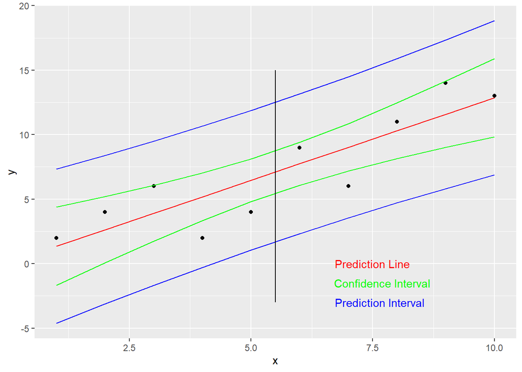

Both the confidence interval and prediction intervals are centered around the prediction line. Neither the prediction interval nor confidence intervals are straight lines, instead they both reach their narrowest points at the mean of the predictor. Here the mean of x is 5.5, which means both the confidence and prediction intervals are at their most narrow point when x is 5.5.

In the standard error formulas for confidence and prediction intervals we see the term MSE. MSE is used as an approximation of the variance of the irreducible error because the irreducible error is not known in practice. If you remember from chapter 1, the irreducible error ($\epsilon$) captures all variables not included in the model that have an effect on the predicted value.

##### Sources:

$James, G., Witten, D., Hastie, T., &amp; Tibshirani, R. (2021). An Introduction to Statistical Leaning: With Applications in R. Springer.$